# Hw1_Ie360

2022-04-13

IE 360 HW1, Mehmet Fatih Sahin, 2018402165

In this homework, the relationship between various time series is examined. One of the crucial indicators for interpreting different economic metrics is exchange rate, USD/TRY, obviously. In order to see how it has effected other metrics, different plots are created and analyzed with the information of correlation.

There is also determined keyword that are assumed to have some relationship with other time series which we got from EVDS web page. Search volume of keywords are obtained from Google Trends.

Time series obtained from EVDS are Exchange rate, Import, Export, and Producer Price Index. The time series obtained from Google Trends is search volume of “Enflasyon”. All of these data start from January of 2013 and ends up with February of 2022.

```r
library(xlsx)
require(ggplot2)
require(ggcorrplot)
require(GGally)
require(data.table)
library(lubridate)
```

```r
data_link=file.choose()
all_data=read.xlsx(data_link,sheetIndex = 1)
all_data=data.table(all_data)
all_data[,DATE:=ym(DATE)]
```

## Including Plots

Below there are various plots which draw Exchange Rate vs each one of Export, Import, and Ppi

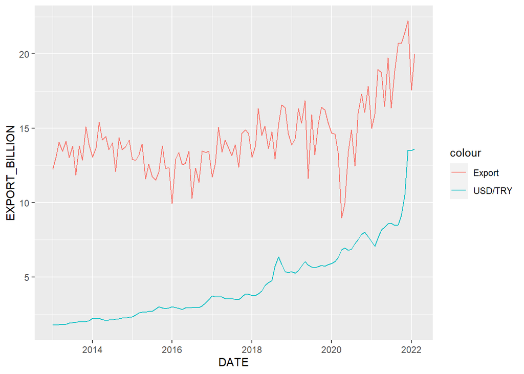

```r
ggplot_1=ggplot(all_data,aes(x=DATE))+geom_line(aes(y=EXPORT_BILLION,color="Export"))+
  geom_line(aes(y=EXC_RATE,color="USD/TRY"))
ggplot_1
```

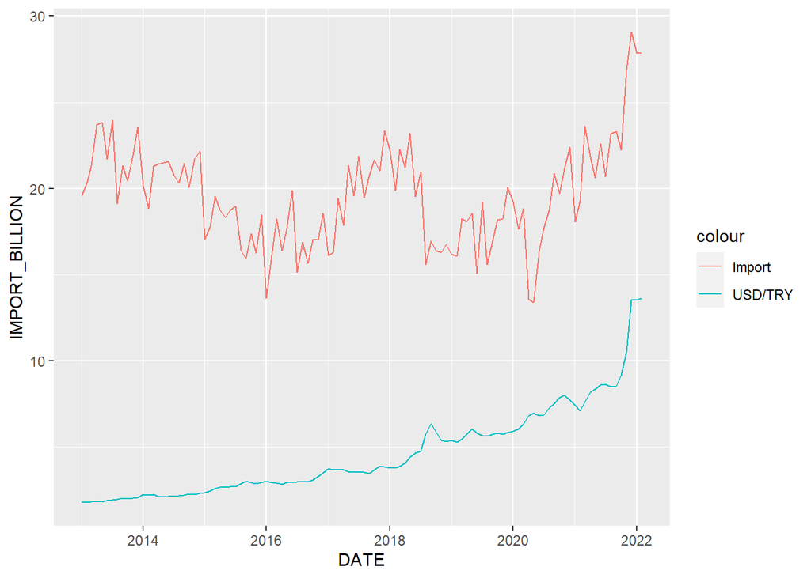

```r
ggplot_2=ggplot(all_data,aes(x=DATE))+geom_line(aes(y=IMPORT_BILLION,color="Import"))+
  geom_line(aes(y=EXC_RATE,color="USD/TRY"))
ggplot_2
```

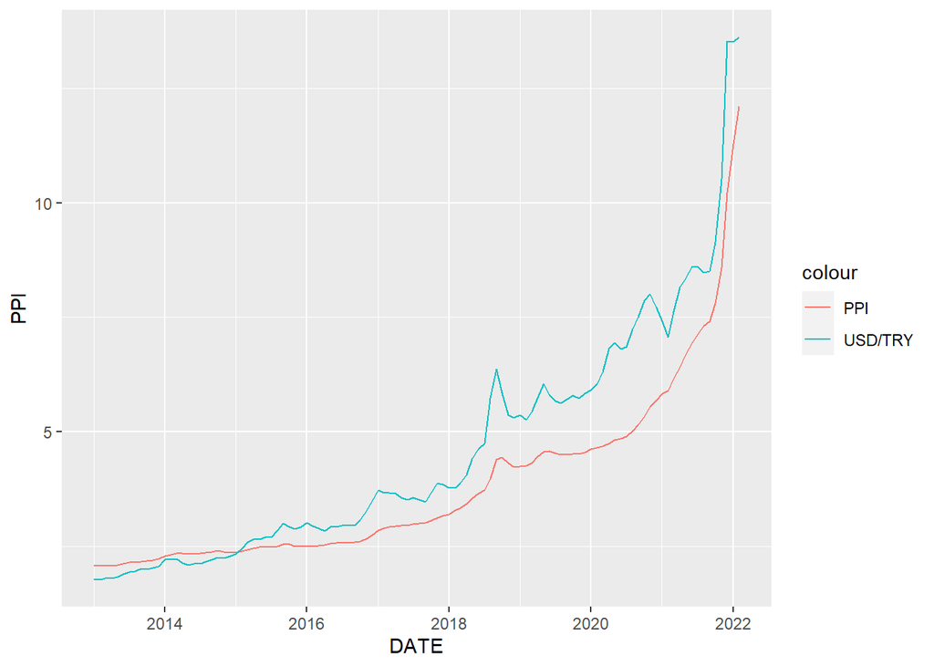

```r
#PPI is in normalized form due to visualization purposes
ggplot3=ggplot(all_data,aes(x=DATE))+geom_line(aes(y=PPI,color="PPI"))+
  geom_line(aes(y=EXC_RATE,color="USD/TRY"))
ggplot3
```

From the above figures, we can easily observe that USD/TRY and PPI are vastly correlated.It is highly significant and intuitive that producer’s cost will dramatically be influenced by the increase in USD.In many production processes in Turkey, there are raw materials coming from other countries.

It also seems appearant that exchange rate and export levels are correlated. However,exchange rate vs import level graph is not that clear. To make it more clear and for interpreting previous graphs’ correlation numerically, it could be useful to execute ggpairs function.

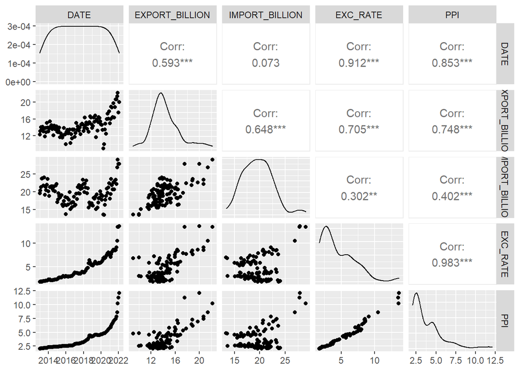

```r
ggpairs(all_data)
```

From the above figure, we can see numerically how much we are right when we say Exchange rate and PPI are correlated,0.98.

We can also see that exchange rate is correlated enough positively with the export amount,0.705. This should stem from the fact that local producers’ products have been becoming cheaper for a buyer in countries using USD. This could be a good indicator if we only consider this phenomenon, however, obviously we should consider with other facts to make a proper analysis. Increase in exchange rate does not lead decrease in import levels,we can see this by the correlation level between import and exchange rate,0.302 This should be because of the necessity of raw materials,local producers have to import some raw materials. Hence, as mentioned before, their costs are increasing dramatically.

Let us examine if Exchange rate has significant autocorrelation or not.

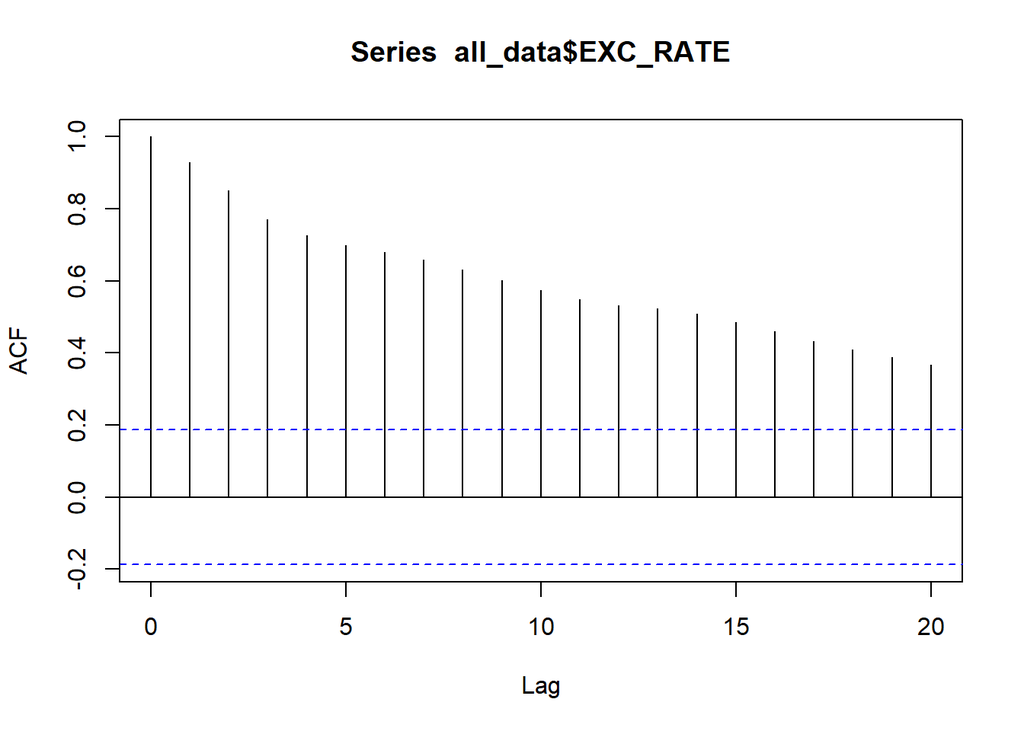

```r
acf(all_data$EXC_RATE)
```

The output of above function shows us that there is a trend obviously but we do not see similar auto correlation between any intervals. This implies that there is not much seasonality. The exact times which depreciation of TRY against USD occurs may not be that systematic, however, there is an obvious pattern showing the depreciation of TRY.

Now, we will examine the relation between search volume of “Enflasyon” and USD/TRY ratio

Since drawing in two different scaled y axis can be misleading, we will draw them separately and then compute correlation.

```r
data_path=file.choose()
search_enflasyon=read.csv(data_path)
search_enflasyon=data.table(search_enflasyon)
search_enflasyon[,Ay:=ym(Ay)]
```

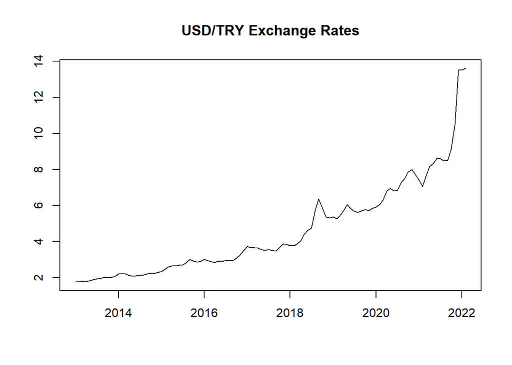

```r
plot(all_data$DATE, all_data$EXC_RATE, type = "l",xlab = " ", ylab = " ", main = "USD/TRY Exchange Rates")
```

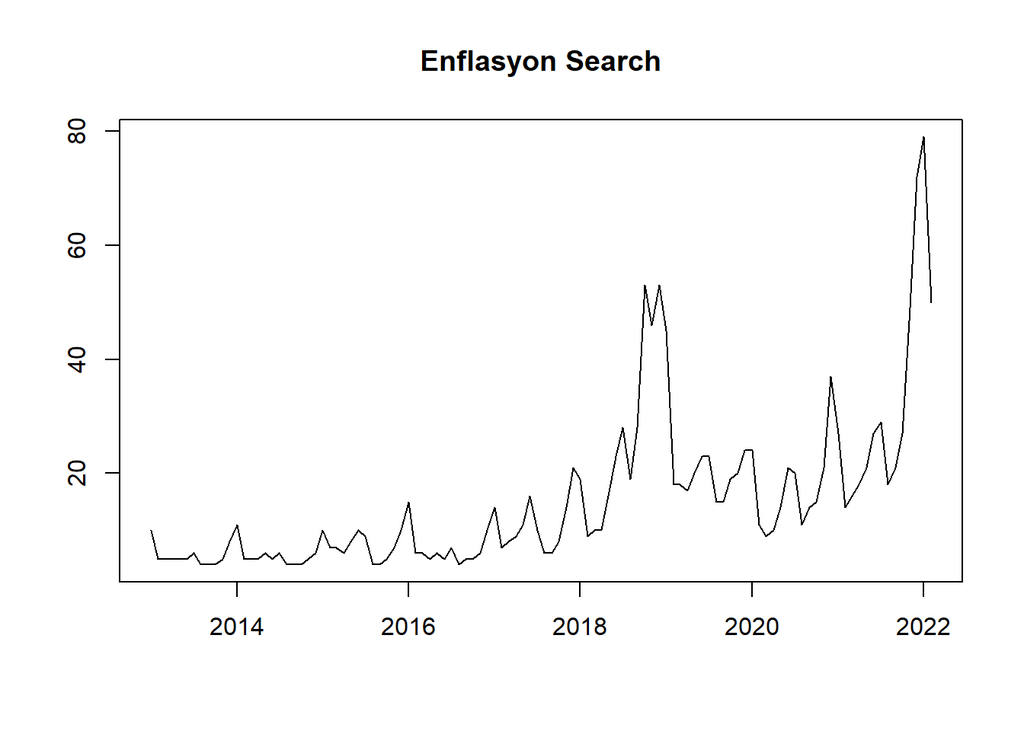

```r
plot(search_enflasyon$Ay,search_enflasyon$enflasyon...Turkiye., type = "l",xlab = " ", ylab = " ", main = "Enflasyon Search")
```

```r
cor(all_data$EXC_RATE,search_enflasyon$enflasyon...Turkiye.)
```

```
## [1] 0.7841071
```

Correlation is high enough, 0.784, which implies that both search volume and exchange rate has same pattern.However, since correlation does not mean causation, it could be useful to exclude the effect of trend and then look at correlation

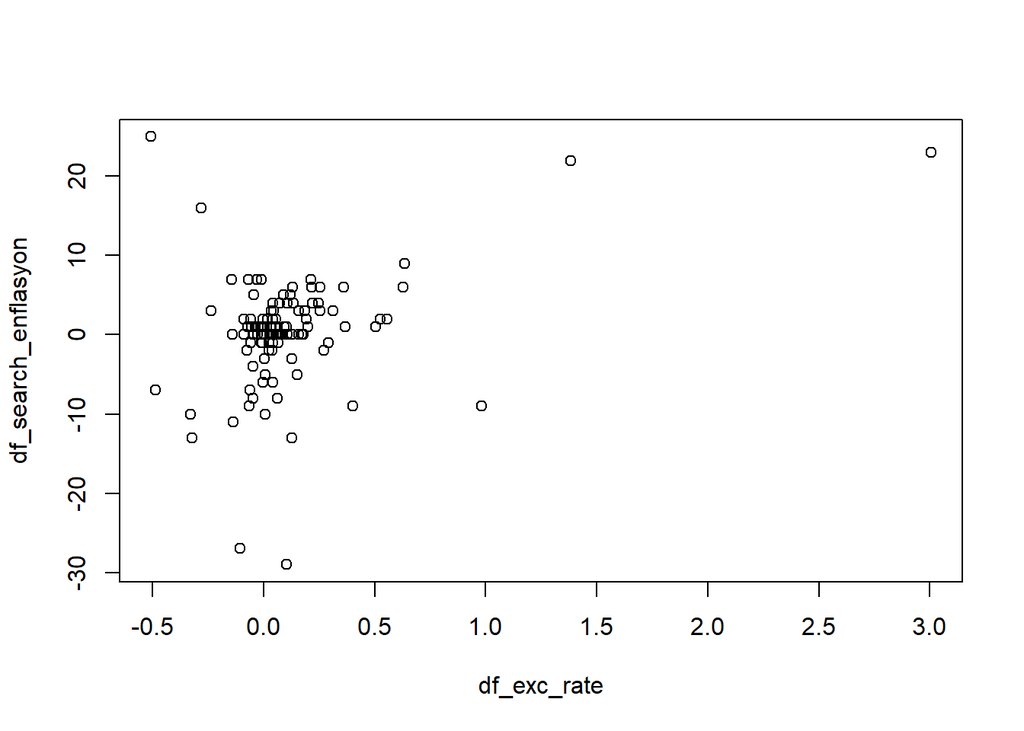

```r
df_exc_rate=diff(all_data$EXC_RATE)
df_search_enflasyon=diff(search_enflasyon$enflasyon...Turkiye.)
plot(df_exc_rate,df_search_enflasyon)
```

```r
cor(df_exc_rate,df_search_enflasyon)
```

```
## [1] 0.3500648
```

By taking the differences of consecutive items in Exchange rate vector and search volume of enflasyon vector,we see that there is not as much as correlation within vectors itself. Although increase in USD/TRY is one of the reasons of increase in inflation, people should have searched more for “enflasyon” when there is extra depreciation of TRY,people tend to accept some amount of increase in USD/TRY and inflation is normal and not search for “enflasyon”unless there are extra changes occur than expected which is common in Turkey. Also, there are other factors that might cause inflation.

Conclusion:

In this homework, we got different time series data from EVDS and Google Trends. It was useful to see the plot first, it leads us to construct hypothesises and we have tested them via various tools. Ggpairs shows us all different combinations of correlations for vectors in our data. At the end, we have used diff function to avoid at least partly from the trend effect and to see the causal relations between exchange rate and search volume for “enflasyon”.